# KEY Homework #8

Data Science for Biologists, Fall 2021

#### Question 1: How does the spread of coffee `uniformity` distributions compare among different coffee processing methods, excluding unknown (`NA`) processing methods?

“Pulped natural / honey” has the lowest standard deviation of 0, implying no spread in its distribution - all uniformity values are the same, so there is no variation. “Other” has the highest standard deviation of 0.821. All standard deviations are relatively low compared to uniformity values of ~10 (as seen in plot), showing that overall there is relatively little spread in any distribution.

```r
# Calculate the sd of uniformity for each processing method, and SHOW the output
coffee %>%
  drop_na(processing_method, uniformity) %>%
  group_by(processing_method) %>%
  summarize(sd_uniformity = sd(uniformity))
```

```
## # A tibble: 5 × 2
##   processing_method         sd_uniformity
##   <chr>                             <dbl>
## 1 Natural / Dry                     0.601
## 2 Other                             0.821
## 3 Pulped natural / honey            0
## 4 Semi-washed / Semi-pulped         0.322
## 5 Washed / Wet                      0.467
```

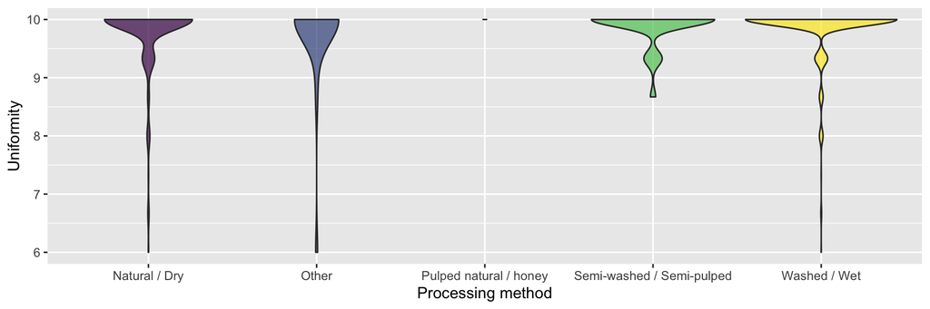

```r
# Plot the **distributions** of uniformity across processing method, as violin for example
coffee %>%
  drop_na(processing_method, uniformity) %>%
  ggplot() +
  aes(x = processing_method, y = uniformity, fill = processing_method) +
  labs(x = "Processing method", y = "Uniformity") +
  geom_violin(alpha = 0.7) +
  scale_fill_viridis_d() +
  theme(legend.position = "none")
```

#### Question 2: Which countries grow Robusta coffees, and how many Robusta coffees are grown in each of these countries?

India grows the most Robusta coffee (13), and Vietnam grows the least (1).

```r
# Count number of Robusta coffees and name column appropriately
coffee %>%
  filter(species ==  "Robusta") %>%
  count(country_of_origin, name = "number_robusta") -> robusta_data
robusta_data
```

```
## # A tibble: 5 × 2
##   country_of_origin number_robusta
##   <chr>                      <int>
## 1 Ecuador                        2
## 2 India                         13
## 3 Uganda                        10
## 4 United States                  2
## 5 Vietnam                        1
```

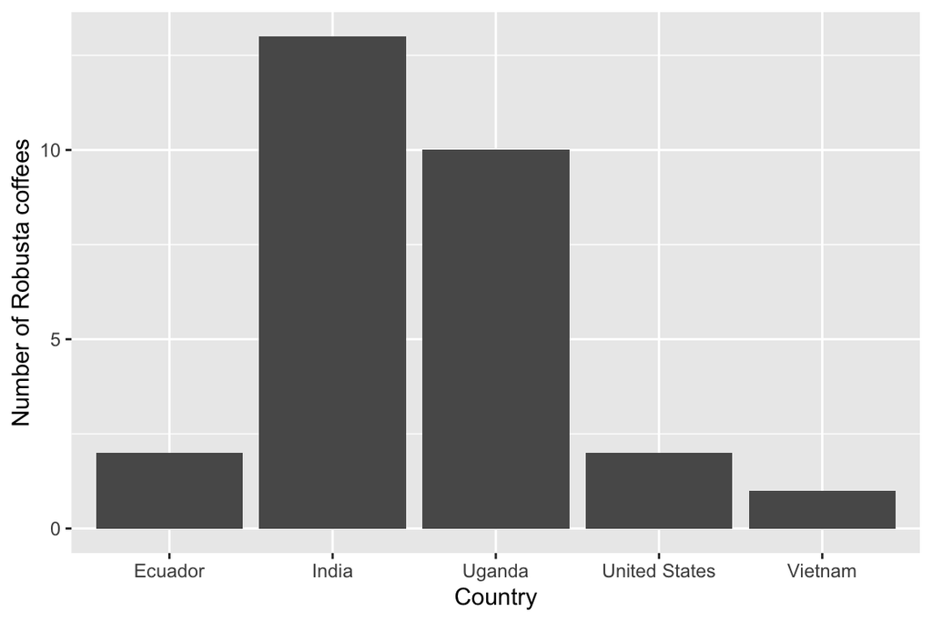

```r
# Plot the data
robusta_data %>%
  ggplot() +
  aes(x =country_of_origin, y = number_robusta) +
  geom_col() +
  labs(x = "Country", y = "Number of Robusta coffees")
```

#### Question 3: Does there appear to be an association between `color` and `moisture` across coffees? In other words, do certain colors have a higher or lower moisture on average?

The “None” color has the highest mean moisture, but all colors have similar mean moistures between 0.84-0.115. There is not a strong association here. Comparing plots, while the barplot shows the literal means, it “hides” the full shape of the data from us. By plotting as a jitter plot (or other type of plot that is not a boxplot!), we see the truth about this data: The moisture distributions *are all bimodal.*

```r
# Calculate mean moisture for all non-NA colors
coffee %>%
  group_by(color) %>%
  drop_na(color) %>%
  summarize(mean_moisture = mean(moisture))
```

```
## # A tibble: 4 × 2
##   color        mean_moisture
##   <chr>                <dbl>
## 1 Blue-Green          0.0842
## 2 Bluish-Green        0.0944
## 3 Green               0.0951
## 4 None                0.115
```

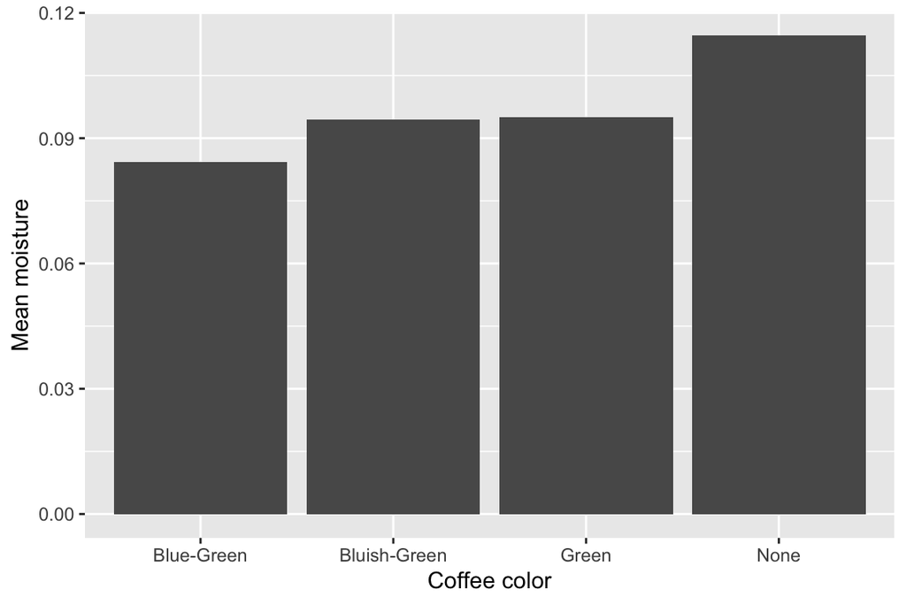

```r
# First, plot the literal mean moistures:
coffee %>%
  group_by(color) %>%
  drop_na(color) %>%
  summarize(mean_moisture = mean(moisture)) %>%
  ggplot() +
  aes(x = color, y = mean_moisture) +
  geom_col() +
  labs(x = "Coffee color", y = "Mean moisture")
```

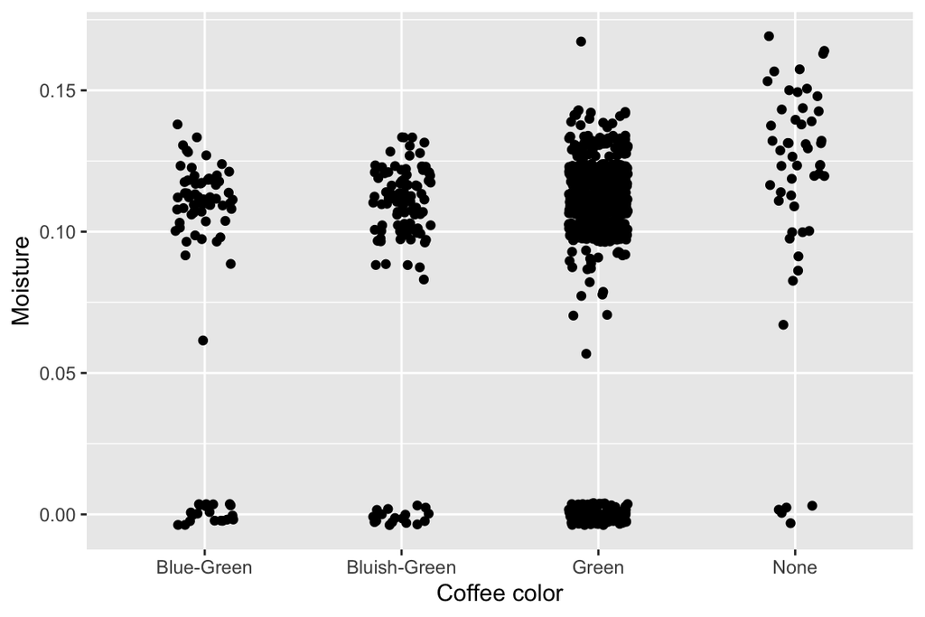

```r
# Second, plot the distributions of moisture values, as jitter for example
coffee %>%
  drop_na(color) %>%
  ggplot(aes(x = color, y = moisture)) +
  geom_jitter(width = 0.15) +
  labs(x = "Coffee color", y = "Moisture")
```

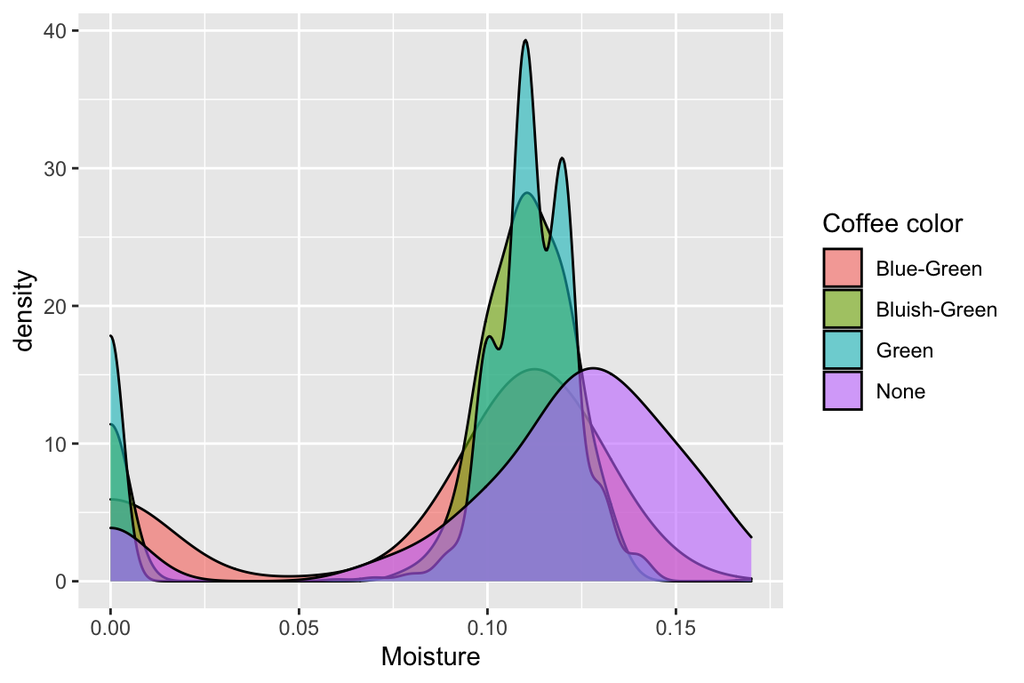

```r
# Or, as density for example:
coffee %>%
  drop_na(color) %>%
  ggplot(aes(fill = color, x = moisture)) +
  geom_density(alpha = 0.6)  +
  labs(fill = "Coffee color", x = "Moisture")
```